# Projet ACP

Damien Fessler

11/13/2021

### Projet ACP - Executive Master “Statistiques et big data” - 2021-2022

#### Introduction, présentation du jeu de données

Le jeu de données est issu de travaux visant à développer des méthodes de détection et de reconnaissance d’accents à partir d’enregistrement audio de mots prononcés par des locuteurs de différentes pays. Les signaux originaux sont des enregistrements de courts mots prononcés par 330 personnes de 6 pays différents (ES, FR, GE, IT, UK, US).

Ces données ont été publiées par Ernest Fokoue, Professeur au Rochester Institute of Technology qui les a utilisées dans un article publié en 2014 et co-écrit avec son collègue Zichen Ma [1]. Le but de l’article est de proposer des algorithmes permettant de classifier de façon binaire les accents de locuteurs « US » ou « non US », à partir de coefficients extraits des enregistrements audio. Plus précisément les données que nous allons manipuler ne sont pas des signaux audio, mais des coefficients « scepstraux » qui résument certaines caractères des signaux permettant de les identifier. Pour obtenir ces coefficients, on fait passer les signaux audio par un certain nombre de filtres et de transformations qui sont détaillées dans [1].

On dispose donc d’une série de douze coefficients qui sont la décomposition des informations du signal audio originel. Ces coefficients constituent les variables explicatives de notre jeu de données. La variable à expliquer sera le type d’accent du locuteur.

L’objectif dans ce travail est de réaliser une ACP sur les 12 variables explicatives, de visualiser des caractéristiques communes à certains accents sur les axes de l’ACP et de chercher à interpréter ces axes. Notons que l’article initial nous fournit déjà un élément de réponse, puisque les auteurs parviennent à construire des classificateurs permettant de distinguer efficacement les accents US des autres accents. On peut donc supposer que les données contiennent de l’information pertinente permettant d’identifier les accents, dans certains cas au moins. On peut aussi espérer retrouver sur nos projections du nuage de points sur les axes de l’ACP un partage entre accents US et non-US.

#### Chargement des données

```r
accentdata <- read.csv("~/Documents/Projet ACP/accent-recognition-mfcc--2/accentdata.csv", sep=";")
```

#### Aperçu des données

```r
head(accentdata)
```

```
##   language        X1        X2       X3        X4        X5        X6        X7
## 1       ES  7.071476 -6.512900 7.650800 11.150783 -7.657312 12.484021 -11.70977
## 2       ES 10.982967 -5.157445 3.952060 11.529381 -7.638047 12.136098 -12.03625
## 3       ES  7.827108 -5.477472 7.816257  9.187592 -7.172511 11.715299 -13.84721
## 4       ES  6.744083 -5.688920 6.546789  9.000183 -6.924963 11.710766 -12.37439
## 5       ES  5.836843 -5.326557 7.472265  8.847440 -6.773244 12.677218 -12.31506
## 6       ES  6.267089 -4.227738 7.227741 10.069418 -6.953871  9.384771 -15.34154
##         X8         X9       X10        X11       X12
## 1 3.426596  1.4627152 -2.812753  0.8665378 -5.244274
## 2 3.491943  0.5954408 -4.508811  2.3321470 -6.221857
## 3 4.574075 -1.6875593 -7.204041 -0.0118469 -6.463144
## 4 6.169879 -0.5447467 -6.019237  1.3585595 -6.356441
## 5 4.416344  0.1934999 -3.644812  2.1512386 -6.816310
## 6 6.718533 -0.4509516 -7.177585  2.5387129 -3.550536
```

#### Résumé des données

```r
summary(accentdata)
```

```
##    language               X1               X2                X3
##  Length:329         Min.   :-6.068   Min.   :-14.973   Min.   :-6.187
##  Class :character   1st Qu.: 2.066   1st Qu.: -6.516   1st Qu.: 0.137
##  Mode  :character   Median : 4.954   Median : -4.253   Median : 2.029
##                     Mean   : 5.645   Mean   : -4.271   Mean   : 2.635
##                     3rd Qu.: 9.794   3rd Qu.: -1.560   3rd Qu.: 4.178
##                     Max.   :17.750   Max.   :  3.571   Max.   :17.066
##        X4               X5                X6               X7
##  Min.   :-8.844   Min.   :-15.657   Min.   :-3.529   Min.   :-15.366
##  1st Qu.: 4.701   1st Qu.: -8.418   1st Qu.: 8.644   1st Qu.:-11.121
##  Median : 7.805   Median : -6.787   Median :10.379   Median : -9.710
##  Mean   : 7.200   Mean   : -5.649   Mean   : 9.810   Mean   : -9.408
##  3rd Qu.:10.129   3rd Qu.: -4.463   3rd Qu.:11.784   3rd Qu.: -7.989
##  Max.   :16.179   Max.   :  7.913   Max.   :21.446   Max.   : -0.424
##        X8               X9               X10               X11
##  Min.   :-2.874   Min.   :-15.511   Min.   :-11.429   Min.   :-13.664
##  1st Qu.: 3.482   1st Qu.: -1.749   1st Qu.: -5.084   1st Qu.:  1.198
##  Median : 4.843   Median : -0.390   Median : -3.323   Median :  3.170
##  Mean   : 5.117   Mean   : -1.229   Mean   : -2.362   Mean   :  2.431
##  3rd Qu.: 6.589   3rd Qu.:  0.780   3rd Qu.: -1.506   3rd Qu.:  4.673
##  Max.   :13.846   Max.   :  4.790   Max.   : 16.326   Max.   :  9.166
##       X12
##  Min.   :-13.724
##  1st Qu.: -5.941
##  Median : -4.374
##  Mean   : -3.980
##  3rd Qu.: -2.192
##  Max.   :  5.259
```

La première colonne est la nationalité (ou l’origine) du locuteur dont on a enregistré la voix.

Concernant les variables quantitatives, on observe que les différences d’amplitudes des variables (Max - Min) n’est pas très élevée: celle-ci oscille entre +/- 15 pour X7 et 27 pour X10. Compte tenu du fait, par ailleurs, que ces différentes variables sont exprimées dans la même unité, la question se pose de réaliser une ACP normée ou non normée. Ce choix n’est a priori pas évident: d’un côté une ACP non-normée engage le risque de donner trop d’importance aux variables ayant les plus grandes amplitudes. D’un autre côté, avec une ACP normée, on prend le risque de se priver d’information utile pour interpréter la variabilité du jeu de données. Nous reviendrons sur ce point.

#### Première représentation des données (1): Boxplot

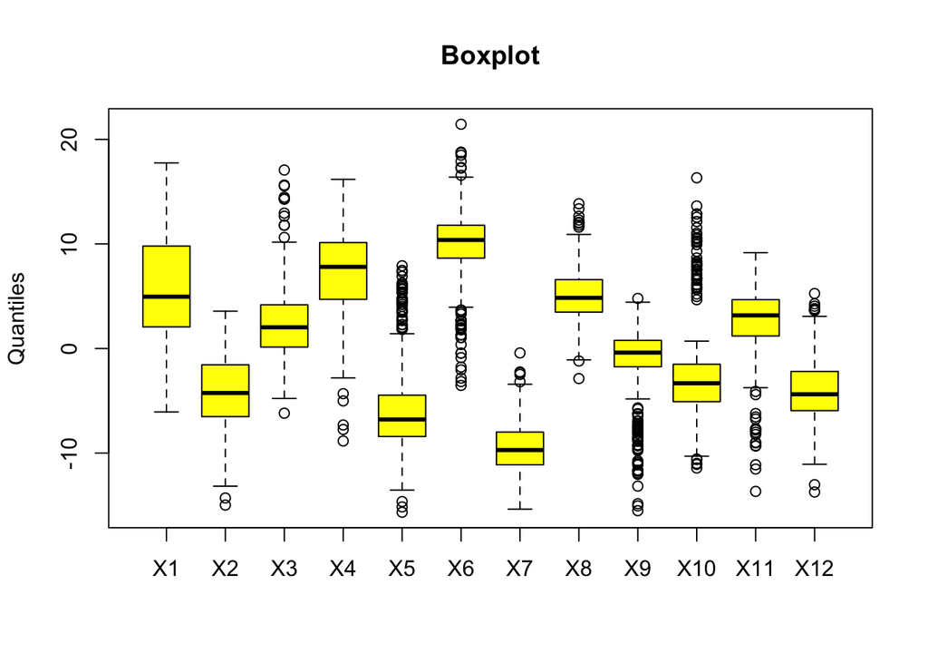

```r
boxplot(accentdata[,c('X1','X2','X3','X4','X5','X6','X7','X8','X9','X10','X11','X12')],
col = c("yellow"),
main = paste("Boxplot"),
ylab = "Quantiles")
```

#### Première représentation des données (2): Histogrammes

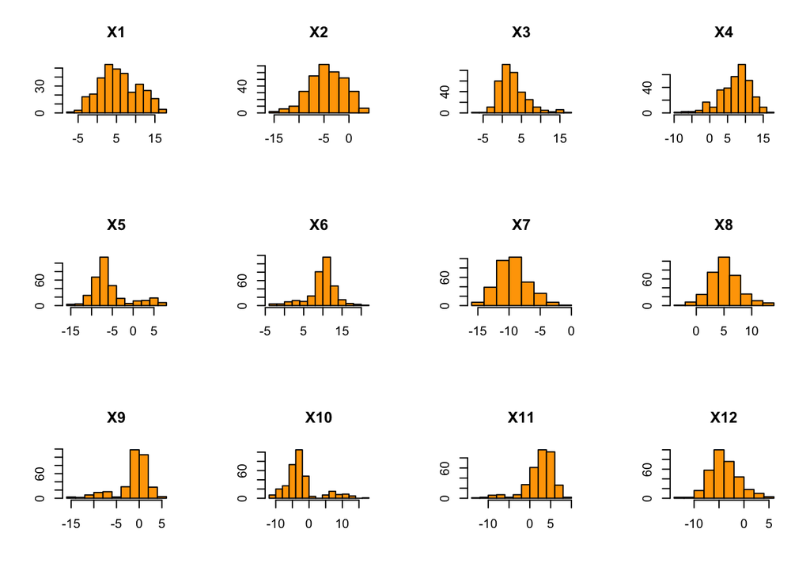

```r
par(mfrow=c(3,4))
hist(accentdata$X1,main='X1', col=c("orange"),xlab=NULL,ylab=NULL)
hist(accentdata$X2,main='X2', col=c("orange"),xlab=NULL,ylab=NULL)
hist(accentdata$X3,main='X3', col=c("orange"),xlab=NULL,ylab=NULL)
hist(accentdata$X4,main='X4', col=c("orange"),xlab=NULL,ylab=NULL)
hist(accentdata$X5,main='X5', col=c("orange"),xlab=NULL,ylab=NULL)
hist(accentdata$X6,main='X6', col=c("orange"),xlab=NULL,ylab=NULL)
hist(accentdata$X7,main='X7', col=c("orange"),xlab=NULL,ylab=NULL)
hist(accentdata$X8,main='X8', col=c("orange"),xlab=NULL,ylab=NULL)
hist(accentdata$X9,main='X9', col=c("orange"),xlab=NULL,ylab=NULL)
hist(accentdata$X10,main='X10', col=c("orange"),xlab=NULL,ylab=NULL)
hist(accentdata$X11,main='X11', col=c("orange"),xlab=NULL,ylab=NULL)
hist(accentdata$X12,main='X12', col=c("orange"),xlab=NULL,ylab=NULL)
```

#### Matrice de corrélation

```r
accentdata.num = accentdata[,-1] ##on supprime la première colonne##
C = cor(accentdata.num)
library(corrplot)
cor_mat=matrix(round(C,digits=2),nrow=12)
row.names(cor_mat) =c("X1","X2","X3","X4","X5","X6","X7","X8","X9","X10","X11","X12")
colnames(cor_mat) =row.names(cor_mat)
cor_mat
```

```
##        X1    X2    X3    X4    X5    X6    X7    X8    X9   X10   X11   X12
## X1   1.00 -0.52  0.11  0.47 -0.42  0.37  0.08 -0.47  0.39 -0.36  0.16 -0.24
## X2  -0.52  1.00 -0.48 -0.13  0.09 -0.11  0.05  0.35 -0.11  0.08 -0.01  0.02
## X3   0.11 -0.48  1.00 -0.30  0.33 -0.32  0.13  0.04 -0.30  0.37 -0.60  0.17
## X4   0.47 -0.13 -0.30  1.00 -0.52  0.59 -0.28 -0.32  0.67 -0.74  0.56 -0.44
## X5  -0.42  0.09  0.33 -0.52  1.00 -0.60  0.41  0.44 -0.77  0.74 -0.53  0.44
## X6   0.37 -0.11 -0.32  0.59 -0.60  1.00 -0.51 -0.40  0.71 -0.71  0.63 -0.54
## X7   0.08  0.05  0.13 -0.28  0.41 -0.51  1.00  0.22 -0.53  0.53 -0.41  0.45
## X8  -0.47  0.35  0.04 -0.32  0.44 -0.40  0.22  1.00 -0.52  0.30 -0.03  0.06
## X9   0.39 -0.11 -0.30  0.67 -0.77  0.71 -0.53 -0.52  1.00 -0.76  0.50 -0.41
## X10 -0.36  0.08  0.37 -0.74  0.74 -0.71  0.53  0.30 -0.76  1.00 -0.67  0.44
## X11  0.16 -0.01 -0.60  0.56 -0.53  0.63 -0.41 -0.03  0.50 -0.67  1.00 -0.39
## X12 -0.24  0.02  0.17 -0.44  0.44 -0.54  0.45  0.06 -0.41  0.44 -0.39  1.00
```

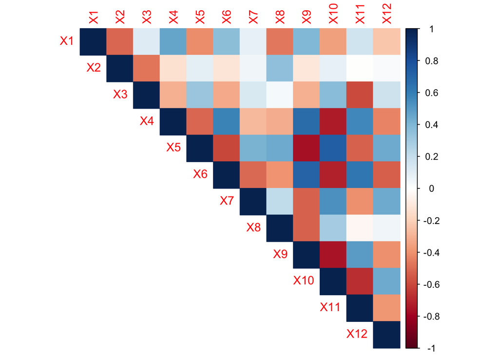

```r
par(mfrow=c(1,1))
corrplot(C, method="color",type="upper")
```

```r
cor_mat=matrix(round(C,digits=2),nrow=12)
row.names(cor_mat) =c("X1","X2","X3","X4","X5","X6","X7","X8","X9","X10","X11","X12")
colnames(cor_mat) =row.names(cor_mat)
```

On passe à l’ACP.

### ACP: Visualisation du nuage des individus projeté et du cercle des corrélations

Nous choisissons par commencer par réaliser une ACP normée et une ACP non-normée afin de comparer leurs résultats.

#### ACP normée

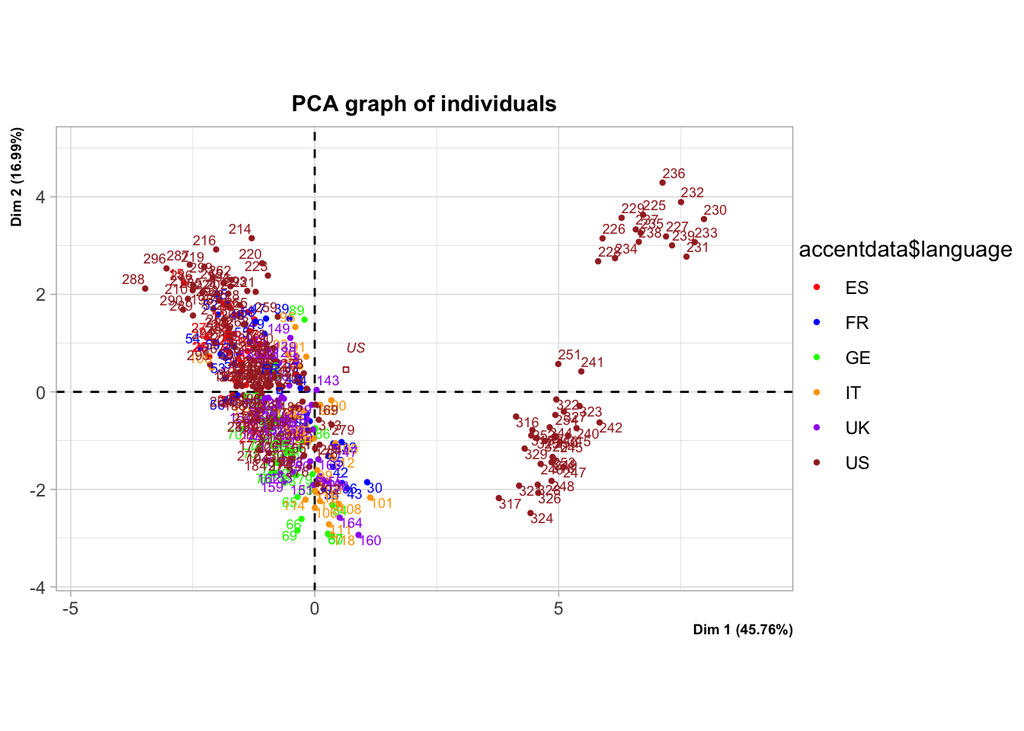

```r
library(FactoMineR)
X.comp = cbind(accentdata.num,accentdata$language)
res.pca = PCA (X.comp, quali.sup=13, graph=FALSE)
plot(res.pca,cex=0.6,cex.main=1,cex.lab=0.7,cex.axis=0.7, habillage=13,col.hab=c("red","blue","green","orange","purple","brown"))
```

#### ACP non normée

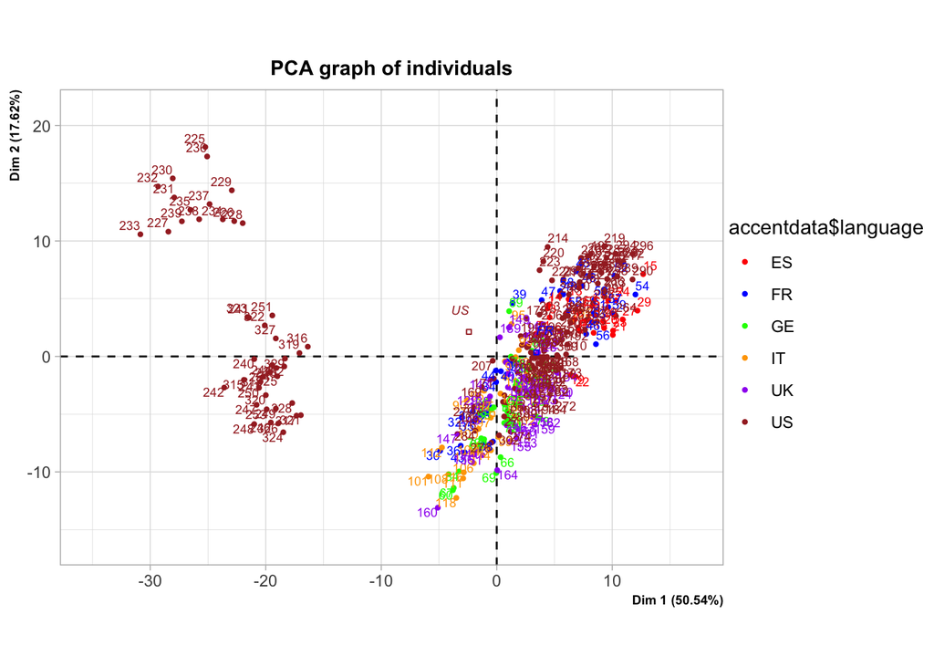

```r
X.comp = cbind(accentdata.num,accentdata$language)
res.pca2 = PCA (X.comp, scale.unit=FALSE,quali.sup=13, graph=FALSE)
plot(res.pca2,choix="ind", cex=0.6,cex.main=1,cex.lab=0.7,cex.axis=0.7, habillage=13,col.hab=c("red","blue","green","orange","purple","brown"))
```

Il apparaît que les résultats des ACP normée et non normée sont très proches. On remarquera toutefois que les deux premiers axes de l’ACP non normée explique une plus grande part de l’inertie, par rapport à l’ACP normée. On choisit donc de retenir l’ACP non normée.

#### ACP: graph des variables

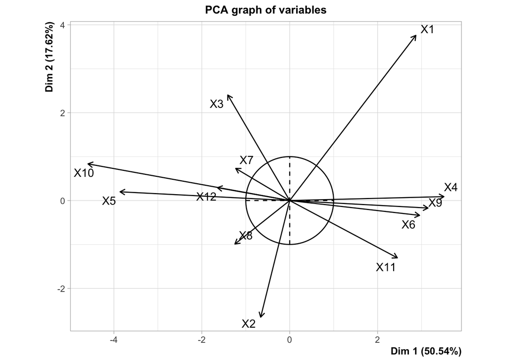

```r
plot(res.pca2,choix="var")
```

Le graph des variables permet d’éclairer les différences entre ACP normée et non normées. En effet il apparaît que l’axe principal est fortement corrélé (négativement) avec la variable X10. Puisque c’est aussi la variable qui a la plus grande amplitude, l’ACP normée, en réduisant cette amplitude, conduisait à se priver d’une part importante d’inertie contenue dans cette variable.

#### ACP: sélection du nombre de composantes

```r
res.pca2$eig
```

```
##         eigenvalue percentage of variance cumulative percentage of variance
## comp 1   89.346573             50.5418828                          50.54188
## comp 2   31.149863             17.6209640                          68.16285
## comp 3   11.868463              6.7137937                          74.87664
## comp 4   10.285695              5.8184481                          80.69509
## comp 5    7.623753              4.3126315                          85.00772
## comp 6    7.254682              4.1038539                          89.11157
## comp 7    6.344184              3.5888003                          92.70037
## comp 8    4.342773              2.4566353                          95.15701
## comp 9    3.079993              1.7423013                          96.89931
## comp 10   2.464734              1.3942596                          98.29357
## comp 11   1.888665              1.0683868                          99.36196
## comp 12   1.127915              0.6380429                         100.00000
```

Si j’utilise le critère de Kaiser, que je ne retiens que les axes dont l’inertie est supérieure à l’inertie moyenne, je ne retiens que les axes 1 et 2.

#### critère du coude

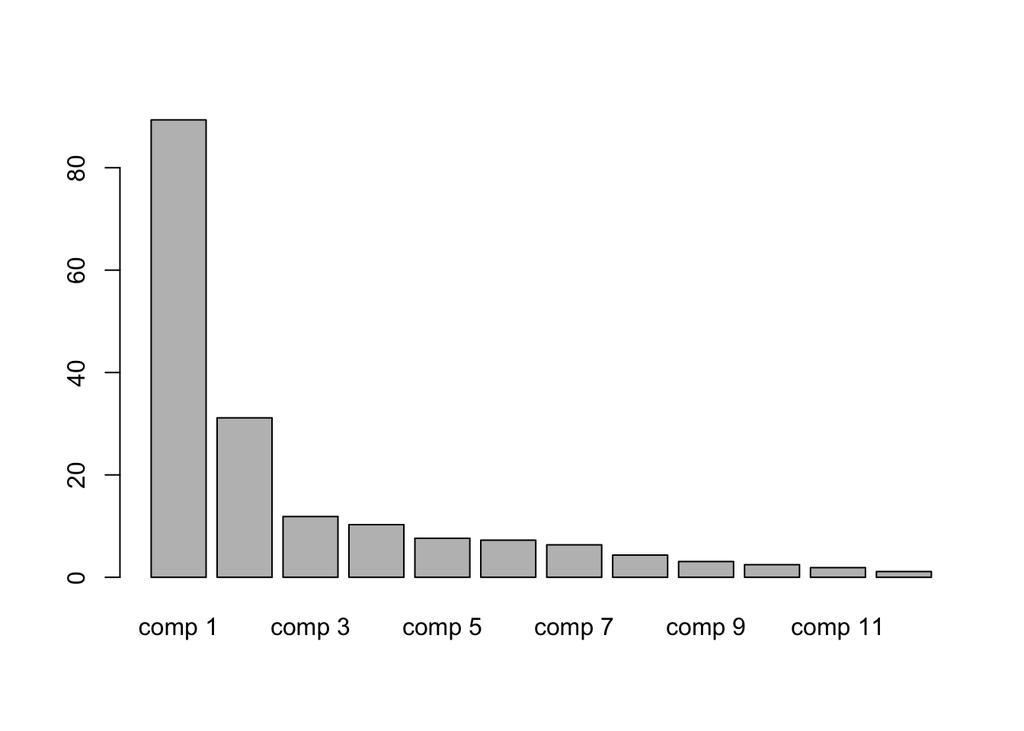

```r
barplot(res.pca2$eig[,1])
```

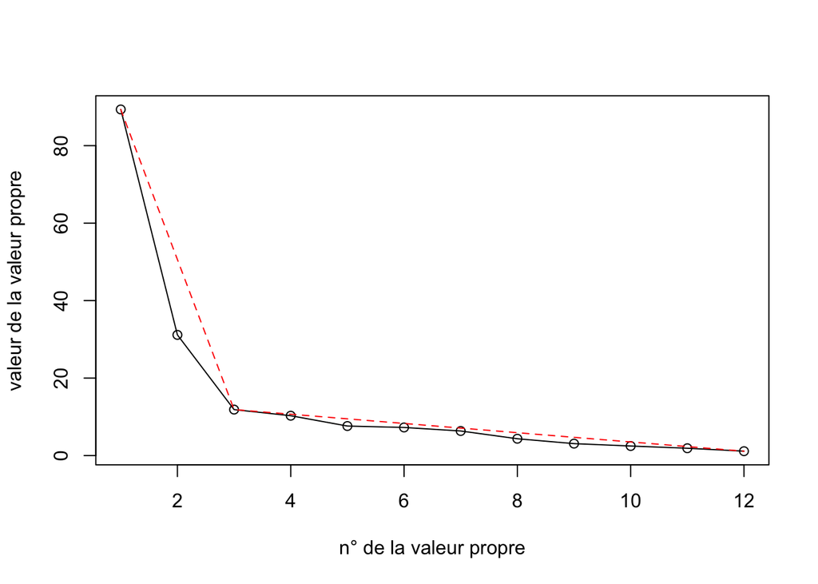

```r
plot(1:12, res.pca2$eig[1:12], pch=1,type="o",xlab="n° de la valeur propre", ylab="valeur de la valeur propre")
x.coude=c(1,3,12)
y.coude=c(res.pca2$eig[1], res.pca2$eig[3], res.pca2$eig[12])
points(x.coude,y.coude,type="l",col="red",lty=2)
```

Le critère du coude comme le critère de Kaiser conduisent à ne garder que les deux premiers axes, qui expliquent 68% de la variabilité. On va désormais s’intéresser à une ACP à 2 composantes. Notons que le graph des individus qui projetait le nuage de points sur le plan formé par les deux premiers axes montrait des individus assez bien groupés en fonction des différents accents, ce qui laisse penser que ces deux premiers axes permettent de reproduire une bonne partie de l’information nécessaire à la classification.

On se restreint donc aux deux premiers axes.

```r
res.pca3 = PCA(X.comp, scale.unit=FALSE, quali.sup=13, ncp=2,graph=FALSE)
```

### Description des axes selon les individus

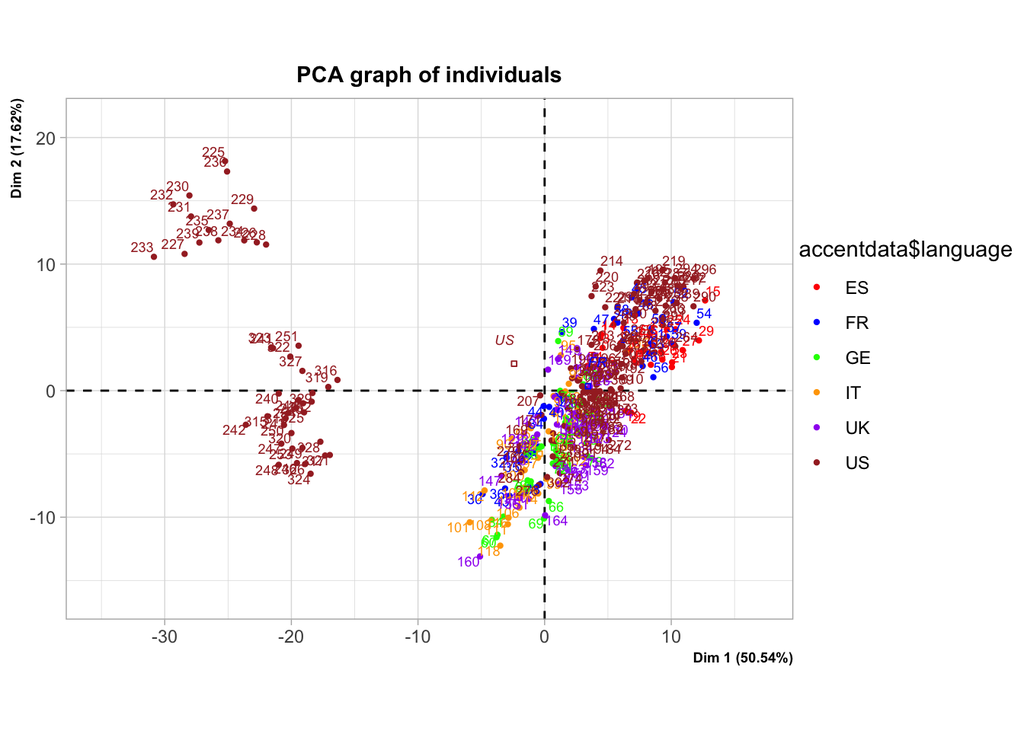

```r
plot(res.pca3,choix="ind", cex=0.6,cex.main=1,cex.lab=0.7,cex.axis=0.7, habillage=13,col.hab=c("red","blue","green","orange","purple","brown"))
```

[une version agrandie de ce graphique est transmise en annexe du présent document]

Ce graph des individus est - sans surprise - identique à celui tracé précédemment. Autre tracé qui peut être utile à l’interprétation: n’afficher seulement les individus dont la contribution à la détermination des axes est élevée.

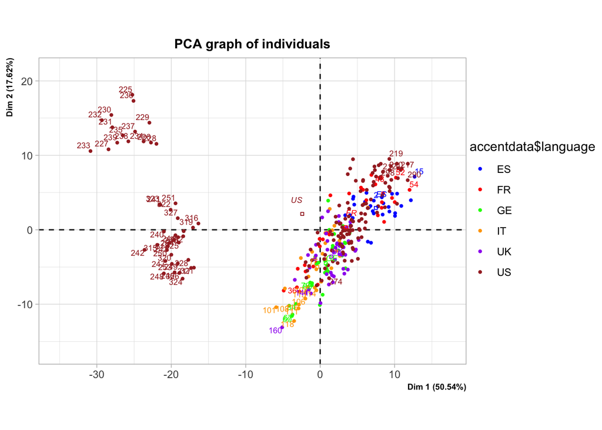

```r
res.pca4 = PCA(X.comp, scale.unit=FALSE, quali.sup=13, ncp=2,graph=FALSE)
plot(res.pca4, habillage=13, cex=0.6,cex.main=1,cex.lab=0.7,cex.axis=0.7, col.hab=c("blue","red","green","orange","purple","brown"), select="cos2 0.7", unselect=0)
```

### Description des axes selon les variables

Dans cette étude, les variables X1 à X12 ne sont pas interprétables directement, mais on peut tout de même tenter de les caractériser

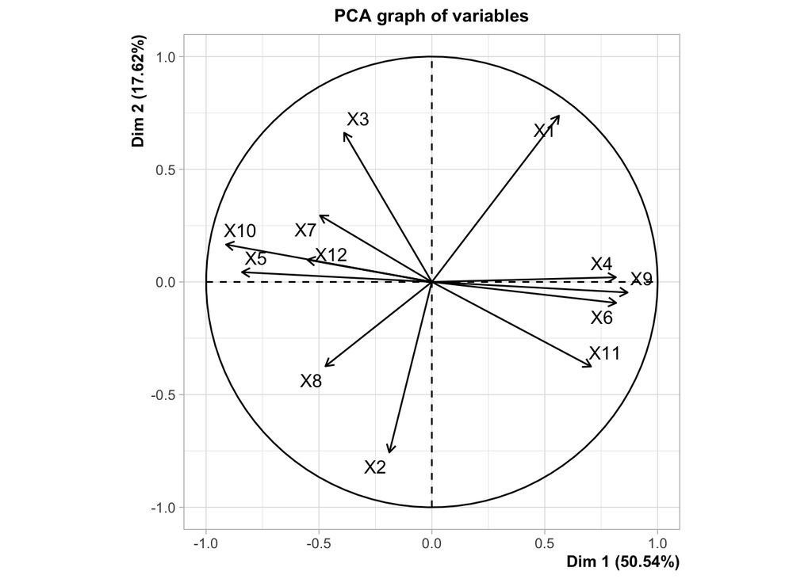

```r
plot(res.pca2, choix="varcor")
```

On va chercher désormais chercher à interpréter les différentes variables en fonction de leurs longueurs (proportionnelle à qualité de représentation élevée dans l’ACP) et de leurs directions, qui reflètent les corrélations entre les différentes variables (l’angle entre les vecteurs formés par les variables et les axes).

L’axe 2 oppose les variables X1 et X3 (corrélées positivement) d’un côté et X2 (corrélées négativement de l’autre). Puisqu’on a vu que l’axe 2 révélait des différence régionales (ou internes) dans les deux grands groupes linguistiques US et non US, on peut considérer que ces 3 variables sont des indices ou des marqueurs de ces différences régionales, sans qu’on puisse vraiment les interpréter comme relevant de groupes linguistiques ou géographiques.

Une remarque générale: il est frappant que l’accent UK ne se distingue pas plus dans cette étude, des autres langues européennes.

### Conclusion

Seconde remarque, le jeu de données est composé pour moitié d’individus US, et pour l’autre moitié d’individus FR, IT, ES, UK et GE. Cette disproportion vient sans doute masquer ou écraser les différences entre les groupes non US. Une piste pour compléter ce travail : on aurait pu faire une ACP avec uniquement les données non US, pour faire apparaître une structuration plus fine des différences entre les caractéristiques des différents accents non-US. Toutefois le petit nombre de données pour chaque sous-groupe aurait beaucoup limité la possibilité d’interpréter les résultats.

### Ressources utilisées

##### Articles

‘[1]’ Ma, Z., & Fokoué, E. (2014). A Comparison of Classifiers in Performing Speaker Accent Recognition Using MFCCs. Open Journal of Statistics, 4, 258-266.

‘[2]’ Dhanalakshmi, P., Palanivel, S., & Ramalingam, V. (2009). Classification of audio signals using SVM and RBFNN. Expert systems with applications, 36(3), 6069-6075.

##### Autres ressources

Videos de la chaine youtube de Valerio Velardo - The Sound of AI

‘[3]’ Mel-Frequency Cepstral Coefficients Explained Easily https://www.youtube.com/watch?v=4_SH2nfbQZ8

‘[4]’ Short-Time Fourier Transform Explained Easily https://www.youtube.com/watch?v=-Yxj3yfvY-4

‘[5]’ Mel Spectrograms Explained Easily https://www.youtube.com/watch?v=9GHCiiDLHQ4&t=32s